# Canny Edge Detection

Canny Edge Detection은 가장 인기 있는 Edge Detection 알고리즘 중 하나 입니다.  
이 알고리즘은 1986년 john F Canny라는 사람에 의해 개발 되었습니다.  
Canny Edge Detection은 아래와 같은 다단계 구조로 되어있습니다.

Canny Edge Detectionは、最も人気のあるEdge Detectionアルゴリズムの一つです。  
このアルゴリズムは1986 年john FCanny という人によって開発されました。  
Canny Edge Detectionは以下のような多段階構造になっています。

#### 1단계 : 노이즈 제거 (Noise Reduction) / 1. 段階 : ノイズ除去

이미지에 노이즈가 있을경우 Edge를 찾기 어려워 지므로,  
5x5 가우시안 필터(Gaussian Fiter)를 이용해서 노이즈를 줄여줍니다.

画像にノイズがあるとEdgeが見つかりにくくなるため、  
5x5 ガウシアンフィルター(Gaussian Fiter)を利用してノイズを低減させます。

#### 2단계 : Gradient 값이 높은 부분 찾기 / 2. 段階 : Gradient値の高い部分を探す

Sobel 커널을 수평,수직 방향으로 적용하여 각 방향의 gradient를 획득 합니다.  
수평방향의 gradient를 Gx, 수직방향의 gradient를 Gy라고 할때  
픽셀 (x,y)에서 edge gradient는 아래의 식에서 구할 수 있습니다.  
Sobelカーネルを水平、垂直方向に適用して、各方向のグレードを獲得します。  
水平方向のgradientをGx、垂直方向のgradientをGyとするとき  
Pixel (x,y)でedge gradientは下記の式から入手できます。

[figure not shown]

#### 3단계 : 최대값이 아닌 픽셀의 값을 0으로 만들기 / 3. 段階 : 最大値でないピクセルの値を0にする

edge 이외의 픽셀들을 제거하기 위해 이미지 전체를 스캔합니다  
먼저 gardient의 최대값을 가진 픽셀을 찾습니다.  
edge以外のピクセルを削除するため、画像全体をスキャンします。  
まず、gardientの最大値を持つピクセルを探します。

[figure not shown]

위 그림에서 A는 수직방향의 edge위에 있는 픽셀입니다.(gradient는 수평 방향)  
B와 C는 gradient방향에 놓인 픽셀 입니다.  
여기서 A 지점에서 gradient 값이 B, C와 비교해서 A의 값이 가장 크면 다음 단계로,  
그렇지 않으면 값을 0으로 바꿔줍니다.  
上図において、Aは垂直方向のedgeの上にあるピクセルです(gradientは水平方向)  
BとCはグラデーション方向に置かれたピクセルです。  
ここで、A地点のgradient値がB、Cと比較して、Aの値が最も大きければ次のステップとして  
そうでなければ値段を0に変えてくれます。

여기서는 3단계에서 실행된 것들이 실제 edge를 판단 했는지 확인 해주는 단계 입니다.  
먼저 문턱값 minVal, maxVal를 2개 지정한후, MaxVal 보다 높으면 edge이며, minVal보다 낮으면 아니라고 판단 합니다  
minVal, maxVal 사이에 있는 값들은 이 픽셀들의 연결 구조를 보고 판단합니다.  
ここでは、3段階で実行されたことが実際にedgeを判断したのかを確認する段階です。  
まずしきい値minVal,maxValを2つ指定した後、MaxValより高ければedgeであり、minValより低ければないと判断します。  
minVal、maxValの間にある値は、このピクセルの連結構造を見て判断します。

[figure not shown]

픽셀들의 연결 구조는 위의 그림처럼 판단 합니다.  
A는 확실히 edge이고, C는 minVal과 maxVla 사이에 있지만 A와 연결 되어있으므로 edge입니다.  
그리고 B는 연결 구조상 edge가 아니므로 제거 합니다.  
ピクセルの連結構造は上図のように判断します。  
Aは確かにedgeで、CはminValとmaxVlaの間にありますがAとつながっているのでedgeです。  
そしてBは連結構造上edgeではないので除去します。

## cv2.Canny(img,minVal,maxVal)

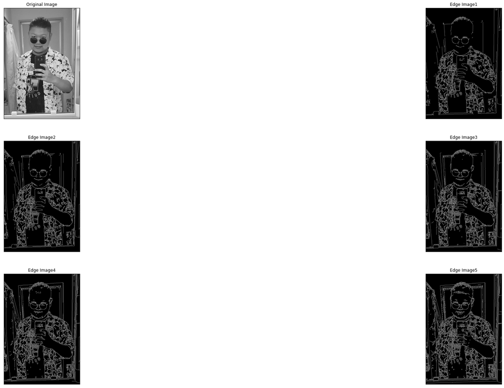

```python
import cv2
import numpy as np
from matplotlib import pyplot as plt

img = cv2.imread('akira.jpg',0)

edges = cv2.Canny(img,200,300)
edges2 = cv2.Canny(img,150,250)
edges3 = cv2.Canny(img,100,200)
edges4 = cv2.Canny(img,80,150)
edges5 = cv2.Canny(img,50,100)

edgesList = [edges, edges2, edges3, edges4, edges5]

plt.figure(figsize=(40, 20))
plt.subplot(3,2,1),plt.imshow(img,cmap = 'gray')
plt.title('Original Image'), plt.xticks([]), plt.yticks([])

for i in range(5):
    plt.subplot(3,2,i+2),plt.imshow(edgesList[i],cmap = 'gray')
    plt.title(f'Edge Image{i+1}'), plt.xticks([]), plt.yticks([])

plt.show()
```